# FigureYa167TumorIndex

小丫画图出品

2020-3-15

欢迎关注“小丫画图”公众号，回复“小白”，看小视频，实现点鼠标跑代码。

小丫微信: epigenomics E-mail: figureya@126.com

作者：SRF

小丫编辑校验

# 需求描述：

作者通过不同肝癌发展模型的RNAseq和转录因子cluster计算出tumor index(`TI:-1~1`，正常~癌)。

要求：①输入建模动物肝癌模型RNAseq数据算出TI②外部验证数据算出TI，重复出下图。

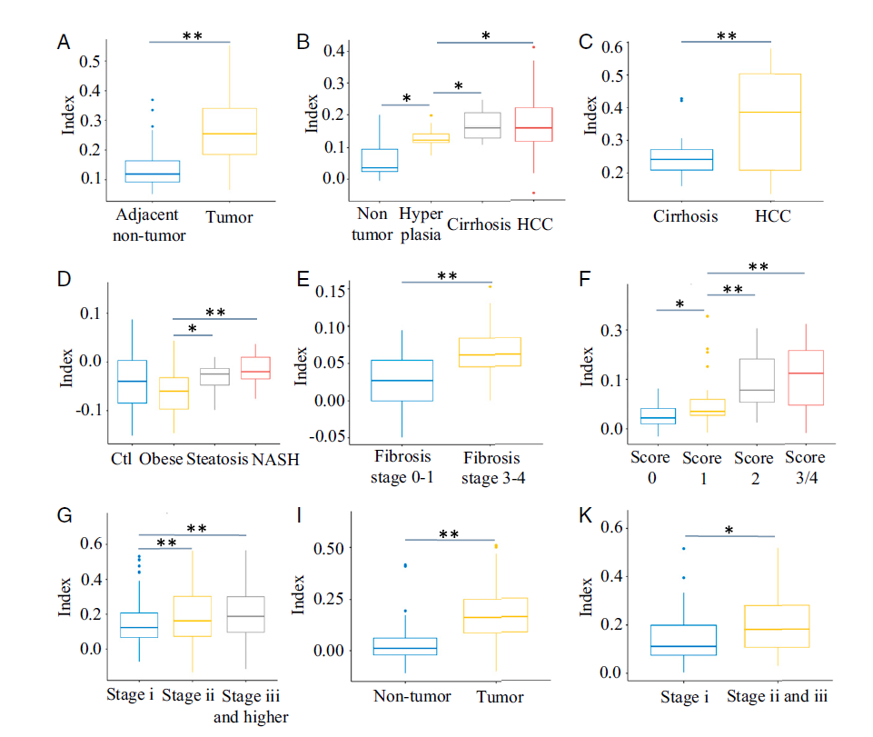

出自http://www.pnas.org/cgi/pmidlookup?view=long&pmid=31843886

Fig.5 TI values of human HCC and precancer patients with steatosis, fibrosis, or NASH. (A) A total of 193 adjacent nontumor liver samples and 240 liver tumor samples were from the GSE36376 dataset. (B) A total of 10 nontumor liver samples, 17 dysplastic liver samples, 13 cirrhotic liver samples, and 35 HCC samples in GSE6764. (C) Cirrhotic liver (n = 34) and HCC (n = 35) samples in GSE56140. (D) Liver samples for control (n = 14), obese (n = 27), steatosis (n = 14), and NASH (n = 18) patients in GSE48452. (E) A total of 72 fibrotic liver samples (fibrosis stages 0–1, n = 40; fibrosis stages 3–4, n = 32) in GSE49541. (F) Hepatitis B virus-related liver fibrosis samples (n = 124) in GSE84044. The pathological Scheuer score of each sample was evaluated, score 0 (n = 43), score 1 (n = 20), score 2 (n = 33), and score 3 and 4 (n = 28). (G) A total of 371 liver tumor samples in the TCGA dataset. Of these, 347 tumor samples had well-documented tumor stages (stage I, n = 171; stage II, n = 86; stage III and more advanced, n = 90).

# 应用场景

1.利用此模型方法学训练自己多阶段/多点的RNAseq数据，或是应用到单细胞数据（如不同分化程度的T细胞）

2.验证数据：如癌和正常的区分度。

文章已经提供了[代码](https://github.com/wanyewang1/Index_model)，但是小伙伴说不会用。

我们这里重新包装了代码，提供比较简便的使用方法。

# 环境设置

加载包

```r
library(GSA)
library(randomForest)
library(preprocessCore)
library(glmnet)
library(ggplot2)
library(tidyverse)
library(GEOquery)
library(ggpubr)
library(ggsci)

Sys.setenv(LANGUAGE = "en") #显示英文报错信息
options(stringsAsFactors = FALSE) #禁止chr转成factor
```

# 训练模型

> 打开`model_training.R`文件查看详情，已添加必要的中文注释，可以用自己的数据来训练模型。

这里概括一下训练模型的重要步骤：

- 1.WT adult liver and HCC的转录组数据用于训练模型。
- 2.鉴定到61个显著改变的TFcluster。
- 3.随机森林确定TFcluster里下游基因对结局变量的贡献度。
- 4.计算每个样本的TF activity.
- 5.计算每个样本的tumor-promoting and -inhibiting strengths.
- 6.广义线性模型拟合，计算index

```r
# source("model_training.R")
# save(Readout, file = "Readout.RData")
(load("Readout.RData"))
```

```
## [1] "Readout"
```

```r
source("Tumorindex.R")
```

# 准备输入数据

data.csv文件太大，请从微云下载https://share.weiyun.com/54ElVDG

```r
#x_train_m为WT&HCC RNAseq，在计算样本的TF activity需要用到。
train <-  read.csv('data.csv') %>% na.omit() %>% .[,c(1,14:16,26:28,32:34,38:40,44:46,59:61,65:67,71:73,89:91,56:58,86:88,96:100)]
train$X <- toupper(as.character(train$X))
y=c(rep(1,27),rep(2,11)) #1:WT 2:HCC
#z_test_m为用户想要计算TI的RNAseq matrix, 第一列是genesymbol，不需要进行标准化。
test <- read.csv("data.csv") %>% na.omit()
rownames(test)[1] <- "X"
test$X <- toupper(as.character(test$X))
x_train_m <- Prepare_input(x_train_m = train, z_test_m = test)$x_train_m
z_test_m <- Prepare_input(x_train_m = train, z_test_m = test)$z_test_m
```

# 运行TI模型

```r
#step3
M_weight <- Prepare_M_weight(z_test_m = z_test_m, Readout = Readout)

#step4
tfactivity <- Calculate_TFactivity(x_train_m = x_train_m,
                                     z_test_m = z_test_m, M_weight = M_weight)
A_TFactivity <- tfactivity$A_TFactivity
sign_TF <- tfactivity$sign_TF

# step5
TFcluster <- Calculate_TFcluster(A_TFactivity = A_TFactivity, sign_TF = sign_TF)

# step6: calcualte tumor index
fit <- Readout[[6]]
Sample_index <- predict(fit, newx = TFcluster, s= c(0.1,0.05))
```

# 画图

对应文章中的Figure 3E

Fig. 3. A tumorigenic index (TI) for quantitative evaluation of liver tumorigenesis. (E) The TI values were calculated from the tumor-promoting and tumor-inhibiting strengths of samples in the third layer.

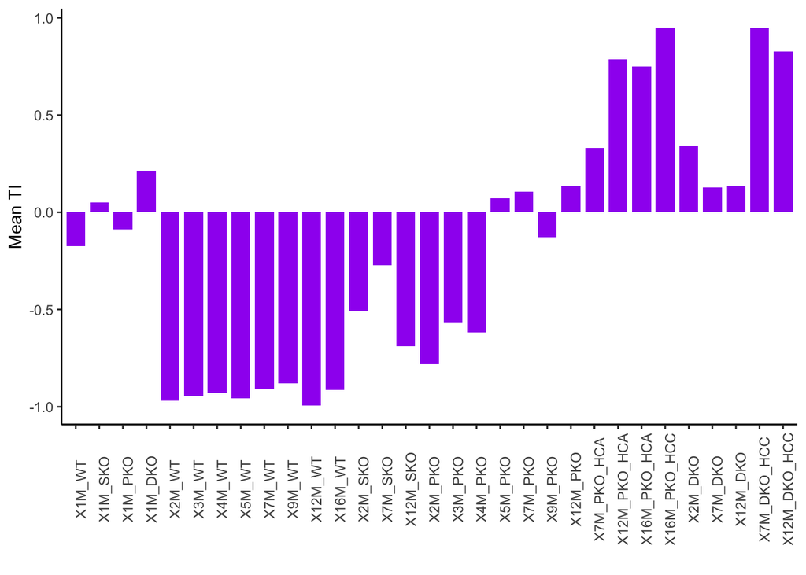

```r
Sample_index <- as.data.frame(Sample_index)
colnames(Sample_index) <- c("s0.1", "s0.05")
Sample_index[, "group"] <- str_replace(rownames(Sample_index), "\\.y$", "") %>% str_replace(., "_[0-9]$", "") %>% str_replace(., "X7M_[0-9]_", "X7M_")

Youth <- c("X1M_WT","X1M_SKO","X1M_PKO", "X1M_DKO");
WT <- c("X2M_WT", "X3M_WT", "X4M_WT", "X5M_WT","X7M_WT", "X9M_WT", "X12M_WT", "X16M_WT")
SKO <- c("X2M_SKO", "X7M_SKO", "X12M_SKO")
PKO <- c("X2M_PKO", "X3M_PKO", "X4M_PKO", "X5M_PKO", "X7M_PKO", "X9M_PKO", "X12M_PKO",
         "X7M_PKO_HCA", "X12M_PKO_HCA", "X16M_PKO_HCA", "X16M_PKO_HCC")
DKO <- c("X2M_DKO","X7M_DKO", "X12M_DKO", "X7M_DKO_HCC", "X12M_DKO_HCC")
group_l <- c(rep("Youth", length(Youth)), rep("WT", length(WT)), rep("SKO", length(SKO)),
                    rep("PKO", length(PKO)), rep("DKO", length(DKO)))
names(group_l)  <- c(Youth, WT, SKO, PKO, DKO)
Sample_index[, "group"] <- factor(Sample_index[, "group"], levels = c(Youth, WT, SKO, PKO, DKO))
Sample_index[, "group_l"] <- group_l[Sample_index$group]

#这里对同一group采用平均值的方法
p.dat <- Sample_index %>% data.table::as.data.table() %>% group_by(., group) %>% summarize(mean0.05 = mean(s0.05))
ggplot(p.dat, aes(x = group, y = mean0.05)) +
  geom_bar(stat = "identity", width = 0.8, fill = "purple") +
  theme_classic() +
  xlab("") + ylab("Mean TI") +
  theme(axis.text.x = element_text(angle = 90))
```

# 应用到自己的数据集

这里我就重复Fig5B和5C好了，其余类似。

GSE6764数据集：10 nontumor liver samples, 17 dysplastic liver samples, 13 cirrhotic liver samples, and 35 HCC samples

GSE56140数据集：Cirrhotic liver (n = 34) and HCC (n = 35) samples

准备数据集：表达矩阵和其临床分组数据，常规的GEO数据集用法，放在Prepare_GEO.R里。

```r
source("Prepare_GEO.R")
gse6764dat <- data.frame(X = rownames(gse6764dat), gse6764dat)
gse6764dat$X <- toupper(as.character(gse6764dat$X))
gse56140dat <- data.frame(X = rownames(gse56140dat), gse56140dat)
gse56140dat$X <- toupper(as.character(gse56140dat$X))
datlist <- list(gse6764dat = gse6764dat, gse56140dat = gse56140dat)

# 保存，便于下次使用
save(datlist, gse56140pdata, gse6764pdata, file = "datlist.RData")
```

## 运行模型

```r
#train
load("datlist.RData")
fit <- Readout[[6]]
train <-  read.csv('data.csv') %>% na.omit() %>% .[,c(1,14:16,26:28,32:34,38:40,44:46,59:61,65:67,71:73,89:91,56:58,86:88,96:100)]
train$X <- toupper(as.character(train$X))
y=c(rep(1,27),rep(2,11)) #1:WT 2:HCC
indexlist <- list()

#calculate index
for (i in 1:length(datlist)){
  test <- datlist[[i]]
  x_train_m <- Prepare_input(x_train_m = train, z_test_m = test)$x_train_m
  z_test_m <- Prepare_input(x_train_m = train, z_test_m = test)$z_test_m
  M_weight <- Prepare_M_weight(z_test_m = z_test_m, Readout = Readout)
  tfactivity <- Calculate_TFactivity(x_train_m = x_train_m,
                                     z_test_m = z_test_m, M_weight = M_weight)
  A_TFactivity <- tfactivity$A_TFactivity
  sign_TF <- tfactivity$sign_TF
  TFcluster <- Calculate_TFcluster(A_TFactivity = A_TFactivity, sign_TF = sign_TF)
  Sample_index <- predict(fit, newx = TFcluster, s= c(0.1,0.05))
  Sample_index <- as.data.frame(Sample_index)
  colnames(Sample_index) <- c("s0.1", "s0.05")
  indexlist[[i]] <- Sample_index
}
names(indexlist) <- names(datlist)
```

## 画图

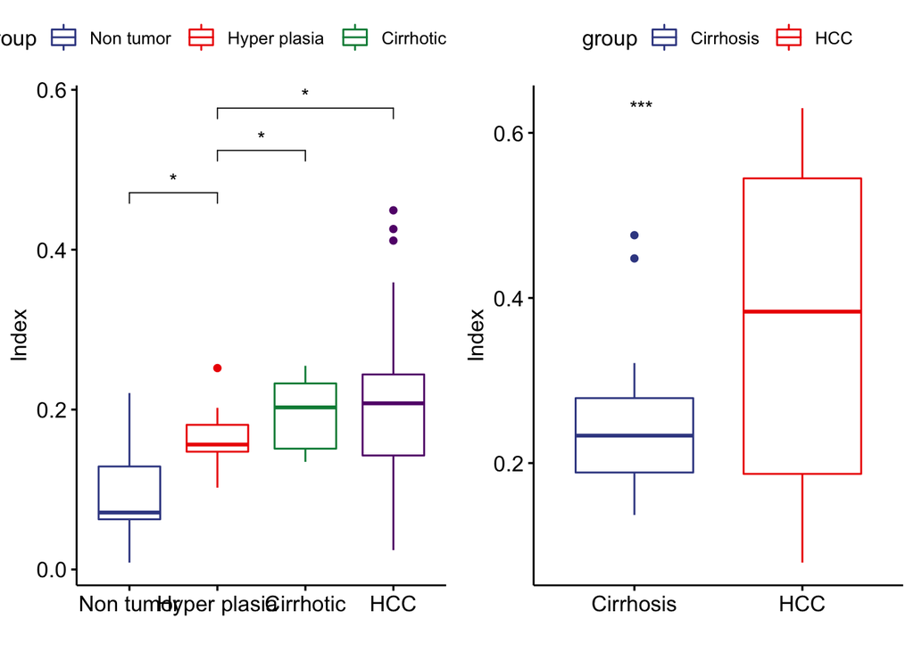

```r
plotdat1 <- merge(indexlist$gse6764dat, gse6764pdata[, c("geo_accession", "characteristics_ch1")],
                  by.x = 0, by.y = 1)

plotdat1$group <-  plotdat1$characteristics_ch1 %>%
  str_replace(., "normal liver tissue", "Non tumor") %>%
  str_replace_all(., c("low-grade dysplastic liver tissue" = "Hyper plasia",
                       "high-grade dysplastic liver tissue" = "Hyper plasia")) %>%
  str_replace_all(., c("cirrhotic liver tissue"="Cirrhotic",
                       "cirrhotic liver tissue from patients without HCC"="Cirrhotic",
                       "Cirrhotic from patients without HCC" = "Cirrhotic")) %>%
  str_replace_all(., c("very early HCC"="HCC",
                       "very advanced HCC"="HCC",
                       "early HCC"="HCC",
                       "advanced HCC"="HCC"))

plotdat1$group <- factor(plotdat1$group, levels = c("Non tumor", "Hyper plasia", "Cirrhotic", "HCC"))
my_comparisons <- list( c("Non tumor", "Hyper plasia"),
                        c("Hyper plasia", "Cirrhotic"),
                        c("Hyper plasia", "HCC") )

p1 <- ggboxplot(plotdat1, x = "group", y = "s0.05", color = "group") +
  stat_compare_means(comparisons = my_comparisons,
                     label = "p.signif", method = "t.test") +
  scale_color_aaas() +
  xlab("") + ylab("Index")

plotdat2 <- merge(indexlist$gse56140dat,
                  gse56140pdata[, c("geo_accession", "characteristics_ch1")],
                  by.x = 0, by.y = 1)

plotdat2$group <- plotdat2$characteristics_ch1 %>%
  str_replace(., "tissue type: cirrhosis", "Cirrhosis") %>%
  str_replace(., "tissue type: hepatocellular carcinoma", "HCC") %>%
  factor(., levels = c("Cirrhosis", "HCC"))

p2 <- ggboxplot(plotdat2, x = "group", y = "s0.05", color = "group") +
  stat_compare_means(label = "p.signif", method = "t.test") +
  scale_color_aaas() + xlab("") + ylab("Index")

# 组图
cowplot::plot_grid(plotlist = list(p1 = p1, p2 = p2), ncol = 2)
```

```r
ggsave("TumorIndex.pdf", width = 12, height = 8)
```